# Prática no R! Roteiro 5 - Regressão Linear

Elaborado por Luis Felipe Bortolatto da Cunha

21 de setembro de 2020

# 1. Introdução

Este roteiro tem como objetivo auxiliar na **análise de regressão linear** no software R.

Para executar a regressão linear vamos utilizar dados demográficos e de consumo de água de 2010, para uma amostra de 4.417 municípios, extraídos do Censo Demográfico (IBGE) e Sistema Nacional de Informações sobre Saneamento (SNIS), para investigar em que medida **o consumo de água está relacionado com a renda**, conforme análise apresentada por [Carmo et al., 2013](https://abrh.s3.sa-east-1.amazonaws.com/Sumarios/155/ea6a64ffc76c211d6b7749ab8444b626_bf87b0b219dd784ffa049f367598e626.pdf).

Uma base de dados pré-processada está disponível no endereço abaixo: https://1drv.ms/u/s!AjettDH-3Gbni9kKwbI1eaRcG3MRRw?e=SdtiNN

### 1.1. Instalando e abrindo os pacotes

O software estatístico R já conta com funções básicas que permitem executar uma análise de regressão linear. Mas além das funções básicas, vamos usar os pacotes:

- `tidyverse`: para adicionar o operador `%>%` e a função `select()`
- `performance`: para comparar modelos
- `broom`: para salvar as estatísticas resultantes do modelo

Se você ainda não possui esses pacotes instalados, é necessário executar o comando abaixo para instalar.

```r
install.packages("tidyverse")
install.packages("performance")
install.packages("broom")
```

Após a instalação, você pode importá-los com o uso da função `library()`.

```r
library(tidyverse)
library(performance)
library(broom)
```

### 1.2. Importando os dados

A base de dados pode ser importada conforme as instruções do Roteiro 2.

Como ela está hospedada na nuvem, também pode ser importada com o endereço web como argumento, ao invés do endereço local, conforme o exemplo abaixo. É importante lembrar que a importação pelo endereço web exige conexão com a internet!

```r
agua_rede1 <- read.csv2("https://raw.githubusercontent.com/luisfelipebr/mti/master/dados/agua_rede1.csv",
                   encoding="UTF-8")
```

### 1.3. Explorando os dados

A função `names()` exibe os nomes das variáveis.

```r
names(agua_rede1)
```

```
##  [1] "ID_IBGE"   "DOMICIL"   "REDE"      "PROPREDE"  "ID_SNIS"   "NOME_MUN"
##  [7] "UF"        "REGIAO"    "PIB"       "RENDAPITA" "GINI"      "IDH"
## [13] "IDH_CLASS" "GE012"     "AG001"     "AG020"     "AG022"     "CONSUMO1"
## [19] "CONSUMO2"
```

Como é possível ver após a execução do comando, os nomes das variáveis estão codificados. Mas a tabela abaixo apresenta uma descrição de cada variável.

| Código | Descrição |
| --- | --- |
| ID_IBGE | Código IBGE (7 dígitos) |
| DOMICIL | Quantidade de Domicílios |
| REDE | Quantidade de Domicílios com Acesso à Rede Geral de Água |
| PROPREDE | Proporção de Domicílios com com Acesso à Rede Geral de Água (REDE/DOMICIL) |
| ID_SNIS | Código IBGE (6 dígitos) |
| NOME_MUN | Nome do Município |
| UF | Unidade da Federação |
| REGIAO | Região do País |
| PIB | Produto Interno Bruto 2010 |
| RENDAPITA | Renda per Capita 2010 |
| GINI | Índice GINI 2010 |
| IDH | Índice de Desenvolvimento Humano 2010 |
| IDH_CLASS | Classificação do Índice de Desenvolvimento Humano 2010: Muito Alto >= 0,9; Alto >= 0,8; Médio >= 0,5; Baixo < 0,5. |
| GE012 | População Total Residente no Município |
| AG001 | População Total Atendida com Abastecimento de Água |
| AG020 | Volume Micromedido nas Economias Residenciais Ativas de Agua - 1.000 m3/ano |
| AG022 | Quantidade de Economias Residenciais Ativas Micromedidas |
| CONSUMO1 | Consumo de Água per capita - População Total - m3/ano (AG020/GE012) |
| CONSUMO2 | Consumo de Água per capita - População Atendida - m3/ano (AG020/AG001) |

# 2. Regressão linear simples

Com o código e descrição das variáveis já é possível executar uma **regressão linear simples**.

A regressão linear é uma ferramenta estatística que permite **explorar e inferir a relação de uma variável dependente com variáveis independentes**, a partir da fórmula:

$Y = \beta_0 + \beta_1 X_1$

Onde:

- Y = variável dependente (resposta/saída)
- X = variável independente (indicadora/explicativa/preditora)
- $\beta_0$ = coeficiente do intercepto
- $\beta_1$ = coeficiente da inclinação

Para executar uma regressão linear simples no R usaremos a função `lm()`, salvando os resultados no objeto `modelo1`. São necessários os argumentos: `formula` que indica as variaveis seguindo a estrutura “Y ~ X”, `data` que indica a base de dados e adicionalmente foi especificado o argumento `na.action = na.exclude` para excluir os valores faltantes (NA).

```r
modelo1 <- lm(formula = CONSUMO1 ~ RENDAPITA, data = agua_rede1, na.action = na.exclude)
```

### 2.1. Análise do ajuste global e coeficientes do modelo

É possível exibir o ajuste global e coeficientes do modelo executando a função `summary()`.

```r
summary(modelo1)
```

```
##
## Call:
## lm(formula = CONSUMO1 ~ RENDAPITA, data = agua_rede1, na.action = na.exclude)
##
## Residuals:
##     Min      1Q  Median      3Q     Max
## -57.650  -7.564  -0.668   6.631 164.515
##
## Coefficients:
##             Estimate Std. Error t value Pr(>|t|)
## (Intercept)  4.25200    0.45548   9.335   <2e-16 ***
## RENDAPITA    0.04100    0.00082  49.997   <2e-16 ***
## ---
## Signif. codes:  0 '***' 0.001 '**' 0.01 '*' 0.05 '.' 0.1 ' ' 1
##
## Residual standard error: 13.14 on 4415 degrees of freedom
##   (1149 observations deleted due to missingness)
## Multiple R-squared:  0.3615, Adjusted R-squared:  0.3614
## F-statistic:  2500 on 1 and 4415 DF,  p-value: < 2.2e-16
```

O **Teste F** é uma medida do quanto o modelo melhorou na previsão de valores comparado com o nível de não precisão do modelo. O modelo apresenta um valor alta de **estatística F** (`2500`) e, ainda mais importante, é que o **p-valor** (`0,00000000000000022`) é menor que o nível de significância (`0,05`), ou seja, existe uma alta probabilidade de que os resultados do modelo não representem um erro amostral.

Sobre os **coeficientes beta**, a estimativa do **$\beta_0$** (coeficiente do intercepto) é `4,252` e do **$\beta_1$** (coeficiente da inclinação) é `0,041`. A tabela de coeficientes também apresenta o erro padrão, estatística t e p-valor, que indicam que os resultados são significativos até para um nível de significância de `0,001`.

Portanto, podemos inferir que, em média, um aumento de R$ 1,00 na renda per capita está associada a um aumento de 0,041 m³/ano no consumo de água (41 litros/ano).

### 2.2. Análise dos resíduos

O modelo de regressão linear assume algumas **hipóteses** sobre os dados de entrada para que seu resultado seja significativo.

1. O modelo é linear nos parâmetros.
2. A amostragem é aleatória.
3. Variação amostral da variável independente.
4. Média condicional do erro igual a zero.
5. O erro tem a mesma variância para qualquer valor da variável explicativa.

Se o modelo for adequado, **os resíduos devem refletir as propriedades impostas pelo termo de erro do modelo**. Portanto, a **análise dos resíduos** se faz necessária para avaliar a adequação do modelo.

O modelo salvo permite a visualização de seis gráficos que auxiliam na análise dos resíduos e hipóteses.

Cada um desses gráficos pode ser acessado com a função `plot()`, com o modelo criado como o primeiro argumento e um segundo argumento `which =` com o número do gráfico a ser acessado.

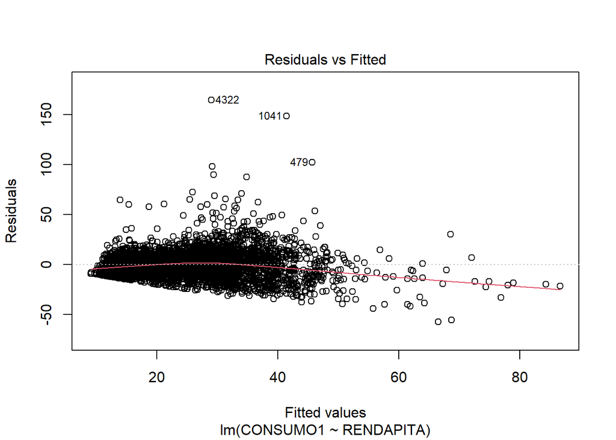

```r
plot(modelo1, which = 1)
```

O primeiro gráfico exibe a relação entre os resíduos e os valores ajustados. Ele permite verificar a não-linearidade do modelo. Um bom modelo possui os valores distribuidos em torno da linha de resíduos igual a zero (linha pontilhada). O modelo aplicado (linha vermelha) desvia um pouco do zero, principalmente nos extremos dos valores ajustados.

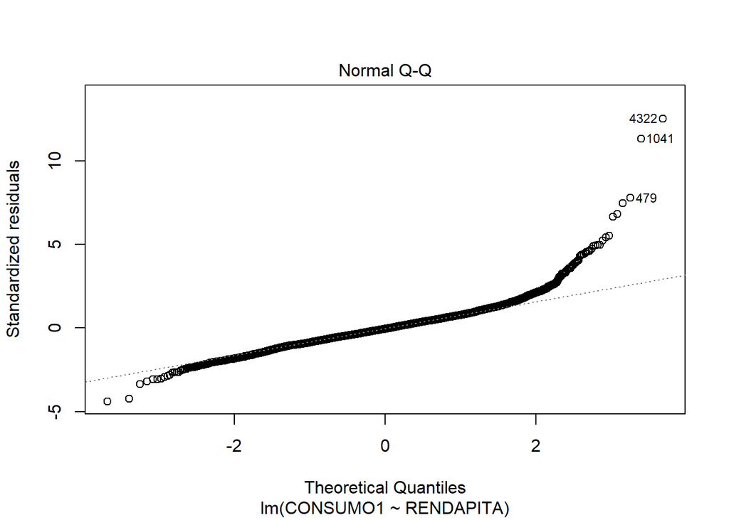

```r
plot(modelo1, which = 2)
```

O segundo gráfico (QQ-plot) exibe os resíduos normalizados e os quantis teóricos da curva normal, ou seja, verifica a hipótese de normalidade dos resíduos. O ideal é que as observações sigam a linha pontilhada.

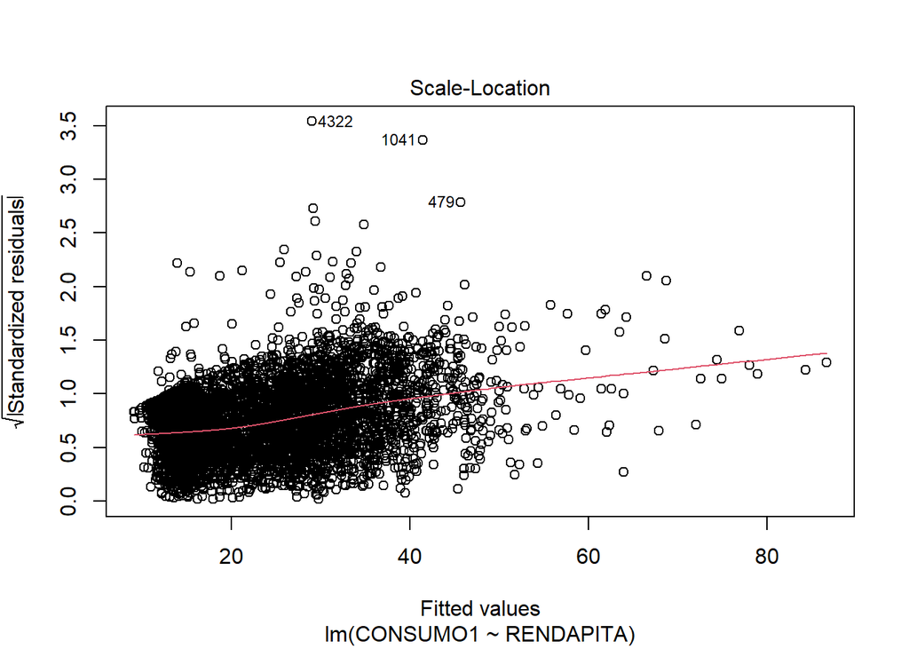

```r
plot(modelo1, which = 3)
```

O terceiro gráfico é útil para verificar a hipótese de homocedasticidade dos resíduos. No modelo ideal, os pontos estão distribuídos uniformemente ao redor da linha vermelha.

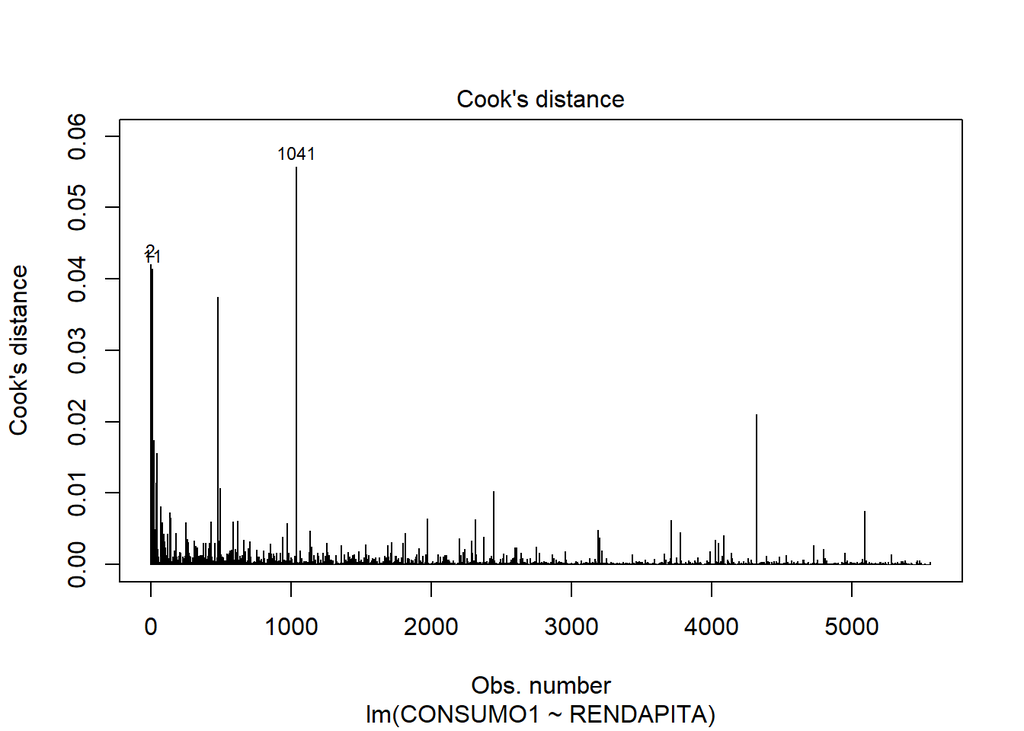

```r
plot(modelo1, which = 4)
```

O quarto gráfico é útil para detectar observações extremas, que possuem alta influência no modelo. As observações mais influentes possuem um valor de distância de Cook maior.

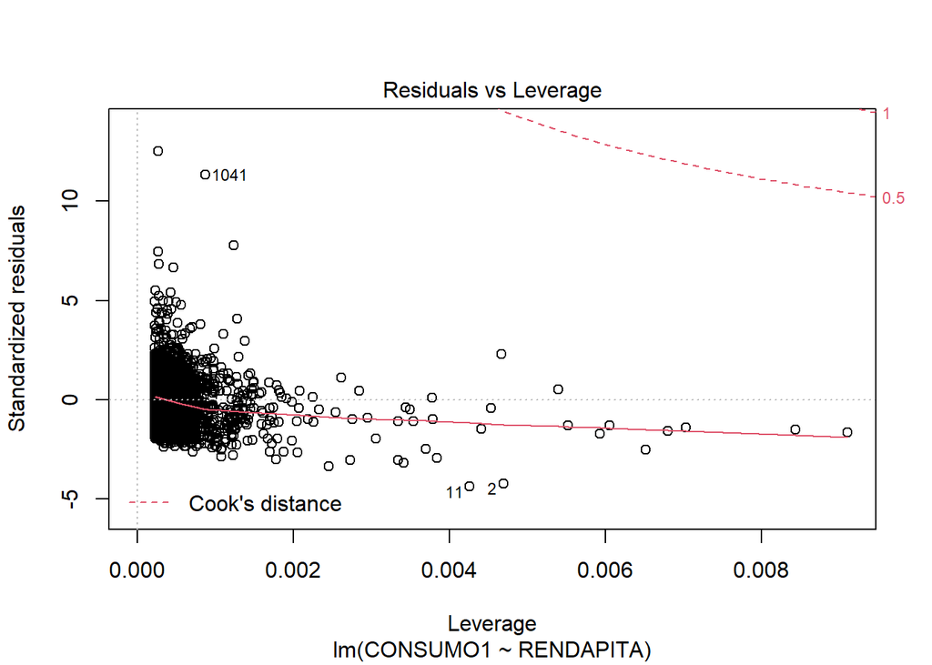

```r
plot(modelo1, which = 5)
```

O quinto gráfico exibe a influência pelos resíduos padronizados. Neste gráfico, as observações mais distantes possuem maior influência.

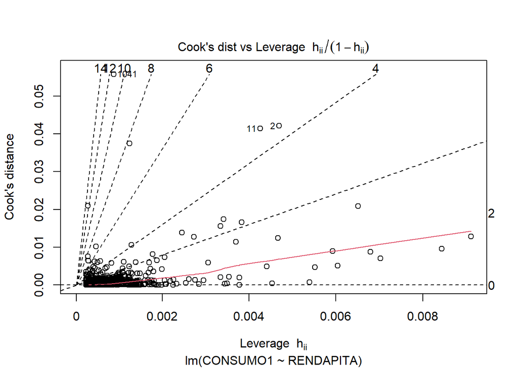

```r
plot(modelo1, which = 6)
```

O sexto gráfico também apresenta uma análise da distância de Cook, permitindo identificar pontos influentes, mas em termos da alavancagem.

### 2.3. Diagrama de dispersão com ajuste

Após a aplicação do modelo, é possível criar um diagrama de dispersão com a linha de tendência (ajuste). Para criar este gráfico, é só executar a função `abline()` após a criação do gráfico.

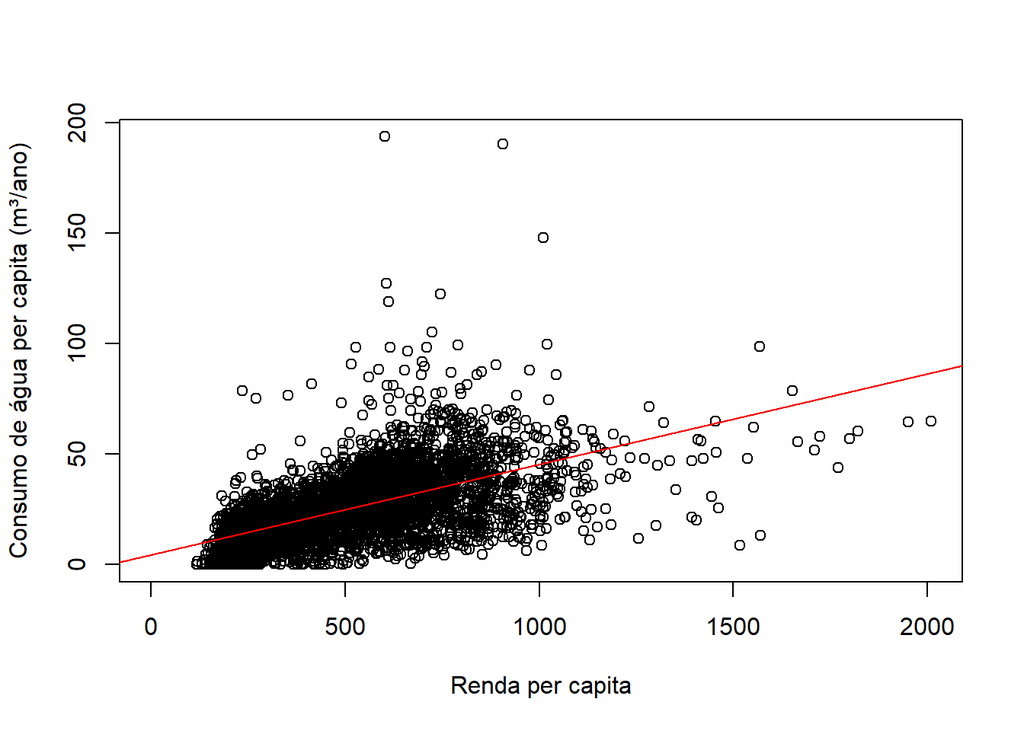

```r
plot(x = agua_rede1$RENDAPITA,
     y = agua_rede1$CONSUMO1,
     xlab = "Renda per capita",
     ylab = "Consumo de água per capita (m³/ano)")
abline(modelo1, col = "red")
```

Também é possível criar esse gráfico com o pacote `ggplot2`, conforme indica o código abaixo:

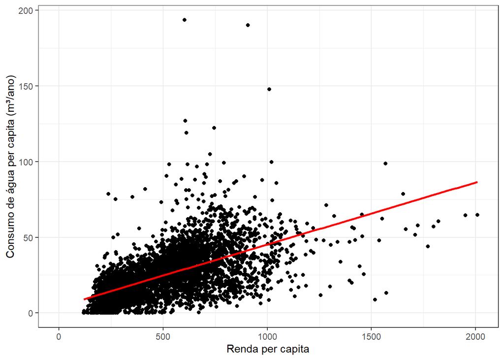

```r
ggplot(data = agua_rede1, aes(x = RENDAPITA, y = CONSUMO1)) +
  geom_point() +
  geom_smooth(data = lm(formula = CONSUMO1 ~ RENDAPITA, data = agua_rede1), method = "lm", col = "red", se = FALSE) +
  theme_bw() +
  xlab("Renda per capita") +
  ylab("Consumo de água per capita (m³/ano)")
```

# 3. Regressão linear múltipla

É possível executar uma **regressão linear múltipla** de forma semelhante à regressão linear simples.

Executando o código abaixo é possível investigar se PROPREDE também influencia em CONSUMO1, além de RENDAPITA. Vamos salvar este modelo como ``modelo2`.

```r
modelo2 <- lm(formula = CONSUMO1 ~ RENDAPITA + PROPREDE, data = agua_rede1, na.action = na.exclude)
```

### 3.1. Resumo do modelo

Para acessar o ajuste e resumo do modelo, use a função `summary()`.

```r
summary(modelo2)
```

```
##
## Call:
## lm(formula = CONSUMO1 ~ RENDAPITA + PROPREDE, data = agua_rede1,
##     na.action = na.exclude)
##
## Residuals:
##     Min      1Q  Median      3Q     Max
## -43.399  -5.934   0.250   5.043 159.926
##
## Coefficients:
##               Estimate Std. Error t value Pr(>|t|)
## (Intercept) -1.825e+01  6.982e-01  -26.15   <2e-16 ***
## RENDAPITA    2.892e-02  7.722e-04   37.45   <2e-16 ***
## PROPREDE     4.023e+01  1.032e+00   39.00   <2e-16 ***
## ---
## Signif. codes:  0 '***' 0.001 '**' 0.01 '*' 0.05 '.' 0.1 ' ' 1
##
## Residual standard error: 11.33 on 4414 degrees of freedom
##   (1149 observations deleted due to missingness)
## Multiple R-squared:  0.5251, Adjusted R-squared:  0.5249
## F-statistic:  2440 on 2 and 4414 DF,  p-value: < 2.2e-16
```

# 4. Comparando modelos

Uma forma de comparar modelos é usando o pacote `performance`. Para comparar os dois modelos (regressão linear simples e regressão linear múltipla), vamos usar a função `compare_performance()` e salvar a comparação como o objeto `tabela_modelos`.

```r
tabela_modelos <- compare_performance(modelo1, modelo2, rank = TRUE)
tabela_modelos
```

```
## # Comparison of Model Performance Indices
##
## Model   | Type |      AIC |      BIC |   R2 | R2_adjusted |  RMSE |        BF | Performance_Score
## -------------------------------------------------------------------------------------------------
## modelo2 |   lm | 33983.66 | 34009.24 | 0.52 |        0.52 | 11.33 | 1.33e+282 |           100.00%
## modelo1 |   lm | 35289.28 | 35308.46 | 0.36 |        0.36 | 13.13 |      1.00 |             0.00%
##
## Model modelo2 (of class lm) performed best with an overall performance score of 100.00%.
```

O modelo 2 (regressão linear múltipla) possui um R² e R² ajustado maior que o modelo 1 (regressão linear simples).

Se quiser salvar essa tabela, é possível fazê-lo com a função `write.csv2()`.

```r
write.csv2(tabela_modelos, "dados/tabela_modelos.csv")
```

Além das métricas apresentadas, também é importante avaliar as hipóteses e redíduos do segundo modelo, conforme as instruções apresentadas na seção 2.2.

# 5. Exportando os resultados do modelo

Ao executar a regressão linear simples ou múltipla, são computadas diversas estatísticas relacionadas a cada observação, por exemplo os valores previstos para Y e os resíduos padronizados.

Existem diversas formas de salvar essas estatísticas, mas recomendamos o uso da função `augment()` do pacote `broom`. Ela exige dois argumentos: `x` que especifica o modelo e `data` que especifica os dados usados para gerar o modelo.

```r
agua_rede1_modelo1 <- augment(x = modelo1, data = agua_rede1)
```

É possível visualizar a base de dados nova com a função `head()`.

```r
head(agua_rede1_modelo1)
```

```
## # A tibble: 6 x 25
##   ID_IBGE DOMICIL   REDE PROPREDE ID_SNIS NOME_MUN UF    REGIAO    PIB RENDAPITA
##     <int>   <int>  <int>    <dbl>   <int> <chr>    <chr> <chr>   <dbl>     <dbl>
## 1 3548807   50492  50472    1.00   354880 "S\xe3o~ SP    Sudes~ 6.69e6     2009.
## 2 4214904    1312    412    0.314  421490 "Rio Fo~ SC    Sul    3.90e4     1571.
## 3 3303302  169237 164768    0.974  330330 "Niter\~ RJ    Sudes~ 5.83e6     1951.
## 4 3205309  108515 107715    0.993  320530 "Vit\xf~ ES    Sudes~ 9.27e6     1821.
## 5 3547304   31610  28728    0.909  354730 "Santan~ SP    Sudes~ 1.09e6     1798.
## 6 4205407  147437 137984    0.936  420540 "Floria~ SC    Sul    4.28e6     1770.
## # ... with 15 more variables: GINI <dbl>, IDH <dbl>, IDH_CLASS <chr>,
## #   GE012 <int>, AG001 <int>, AG020 <dbl>, AG022 <int>, CONSUMO1 <dbl>,
## #   CONSUMO2 <dbl>, .fitted <dbl>, .resid <dbl>, .std.resid <dbl>, .hat <dbl>,
## #   .sigma <dbl>, .cooksd <dbl>
```

Foram adicionadas à base de dados original seis novas variáveis:

- .fitted = Valor ajustado ou previsto
- .resid = A diferença entre os valores observados e ajustados
- .std.resid = Resíduos padronizados
- .hat = Diagonal da matriz de influência
- .sigma = Desvio padrão residual estimado a observação correspondente é excluída do modelo
- .cooksd = Distância de Cook

É possível exportar essa nova tabela com a função `write.csv2`. Ela será usada nas próximas aulas para visualizar a distribuição espacial dos resíduos padronizados.

```r
write.csv2(agua_rede1_modelo1, "dados/agua_rede1_modelo1.csv")
```

# 6. Regressão linear múltipla com o método stepwise

A regressão stepwise consiste em adicionar e remover iterativamente preditores (X) no intuito de encontro o subconjunto de variáveis que resulta no melhor desempenho, que é o modelo que melhor reduz o erro de predição (AIC).

Ela pode ser feita de três formas diferentes:

- Forward selection: começa sem preditores no modelo e adiciona iterativamente os preditores com maior poder preditivo, até não existir melhoria estatisticamente significativa.
- Backward selection: começa com todos os preditores no modelo e remove iterativamente os preditores com menor poder preditivo, resultando em um modelo onde todos os preditores são estatisticamente significativos.
- Stepwise selection: é uma combinação da forward selection e backward selection, sendo o método mais eficaz.

Para mostrar como funciona esse método, vamos aplicar a regressão do tipo stepwise selection em um conjunto de variáveis da base de dados. As variáveis escolhidas foram: RENDAPITA, PROPREDE, PIB, IDH e GINI. Para aplicar o método, primeiro é necessário criar o modelo com todas as variáveis e depois aplicar a função `step()` para obter o modelo com os melhores resultados.

```r
modelo3 <- lm(formula = CONSUMO1 ~ RENDAPITA + PROPREDE + PIB + IDH + GINI, data = agua_rede1, na.action = na.exclude)
```

```r
summary(modelo3)
```

```
##
## Call:
## lm(formula = CONSUMO1 ~ RENDAPITA + PROPREDE + PIB + IDH + GINI,
##     data = agua_rede1, na.action = na.exclude)
##
## Residuals:
##     Min      1Q  Median      3Q     Max
## -43.474  -5.665   0.301   4.870 157.762
##
## Coefficients:
##               Estimate Std. Error t value Pr(>|t|)
## (Intercept) -8.378e+00  2.468e+00  -3.395 0.000693 ***
## RENDAPITA    2.593e-02  1.085e-03  23.905  < 2e-16 ***
## PROPREDE     3.900e+01  1.031e+00  37.837  < 2e-16 ***
## PIB         -7.854e-08  5.744e-08  -1.367 0.171574
## IDH          7.347e+00  2.721e+00   2.700 0.006955 **
## GINI        -2.517e+01  2.858e+00  -8.809  < 2e-16 ***
## ---
## Signif. codes:  0 '***' 0.001 '**' 0.01 '*' 0.05 '.' 0.1 ' ' 1
##
## Residual standard error: 11.19 on 4411 degrees of freedom
##   (1149 observations deleted due to missingness)
## Multiple R-squared:  0.5367, Adjusted R-squared:  0.5362
## F-statistic:  1022 on 5 and 4411 DF,  p-value: < 2.2e-16
```

```r
modelo4 <- step(modelo3, direction = "both")
```

```
## Start:  AIC=21343.2
## CONSUMO1 ~ RENDAPITA + PROPREDE + PIB + IDH + GINI
##
##             Df Sum of Sq    RSS   AIC
## - PIB        1       234 552927 21343
## <none>                   552693 21343
## - IDH        1       914 553607 21349
## - GINI       1      9723 562416 21418
## - RENDAPITA  1     71603 624296 21879
## - PROPREDE   1    179380 732073 22583
##
## Step:  AIC=21343.08
## CONSUMO1 ~ RENDAPITA + PROPREDE + IDH + GINI
##
##             Df Sum of Sq    RSS   AIC
## <none>                   552927 21343
## + PIB        1       234 552693 21343
## - IDH        1       956 553884 21349
## - GINI       1     10325 563252 21423
## - RENDAPITA  1     72685 625612 21887
## - PROPREDE   1    179171 732098 22581
```

```r
summary(modelo4)
```

```
##
## Call:
## lm(formula = CONSUMO1 ~ RENDAPITA + PROPREDE + IDH + GINI, data = agua_rede1,
##     na.action = na.exclude)
##
## Residuals:
##     Min      1Q  Median      3Q     Max
## -43.474  -5.711   0.267   4.874 157.771
##
## Coefficients:
##               Estimate Std. Error t value Pr(>|t|)
## (Intercept)  -8.066709   2.457560  -3.282  0.00104 **
## RENDAPITA     0.025644   0.001065  24.083  < 2e-16 ***
## PROPREDE     38.931694   1.029642  37.811  < 2e-16 ***
## IDH           7.509447   2.718485   2.762  0.00576 **
## GINI        -25.702970   2.831787  -9.077  < 2e-16 ***
## ---
## Signif. codes:  0 '***' 0.001 '**' 0.01 '*' 0.05 '.' 0.1 ' ' 1
##
## Residual standard error: 11.19 on 4412 degrees of freedom
##   (1149 observations deleted due to missingness)
## Multiple R-squared:  0.5366, Adjusted R-squared:  0.5361
## F-statistic:  1277 on 4 and 4412 DF,  p-value: < 2.2e-16
```

Neste caso, a aplicação do método stepwise excluiu a variável PIB, que não representava ganhos na estatística AIC (critério de informação de Akaike) e, coincidentemente, não era significativa (pois o p-valor > 0,05).

Mas é necessário cautela ao aplicar o método stepwise, pois ele permite não pensar no problema o qual buscamos a solução. Além disso, ele pode apresentar: (1) viés na estimativa dos parâmetros, (2) o problema inerente (mas frequentemente esquecido) do teste de múltiplas hipóteses e (3) foco inadequado na busca de um único modelo. Tomando o exemplo apresentado, sabemos que RENDAPITA, PIB, IDH e GINI são altamente correlacionados e não deveriam ser considerados variáveis explicativas de um fenômeno conjuntamente.